# T-distribution

2025-05-27

A t-distributed random variable with $\nu$ degrees of freedom is the ratio of a standard normal variable $Z \sim N(0,1)$ over the square root of a chi-squared variable $Y \sim \chi^2_{\nu}$ divided by its degrees of freedom.

$$T_\nu = \frac{Z}{\sqrt{{Y \over \nu}}}, \quad Z \perp Y$$

Its pdf is given by

$$f(t) = \frac{1}{\sqrt{\pi\nu}
\Gamma({\nu \over 2})}\
\cdot \frac{1}{\left({t^2 \over \nu} + 1\right)^{\frac{\nu+1}{2}} }
\cdot \Gamma\left({\nu+1 \over 2}\right)$$

Its expected variance and mean are:
$$E(T)
= E[h(Z)] E[g(Y)] = 0 \text{ for $\nu > 1$ }$$

$$V(T) = E(Z^2)E\left(\frac{\mu}{Y}
\right) = \frac{\nu}{\nu-2} \text{ for $\nu >2$}$$

Derivation if you’re interested.

The pdf isn’t as important as the distribution itself. This distribution is bell-shaped and symmetric about 0 and *approaches standard normality* as $\nu$ increases.

### Convergence to normality

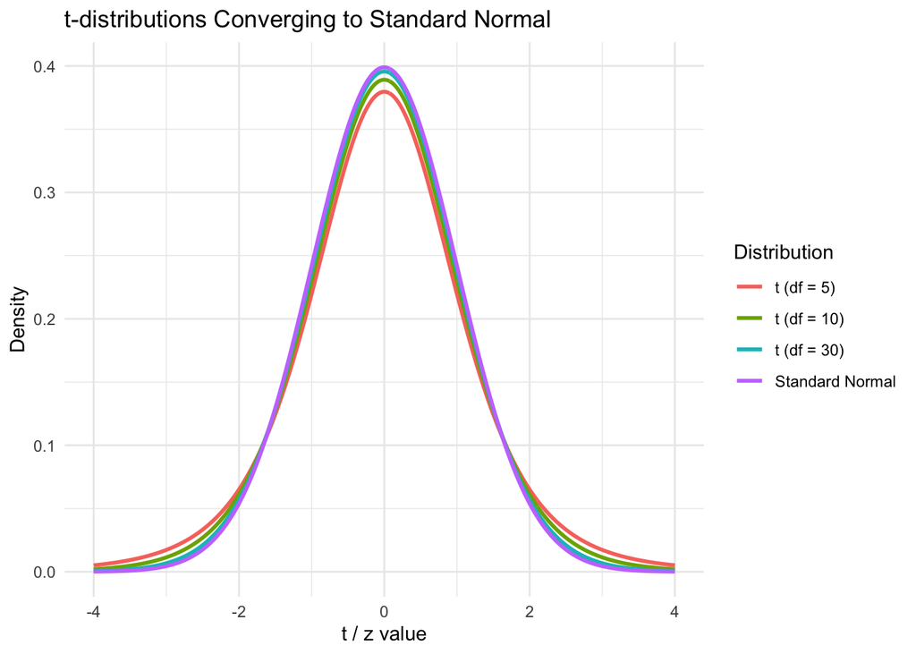

We can also demonstrate this mathematically. The denominator $\sqrt{\frac{Y}{\nu}}$ is the square root of an average of individual Gamma variables $Z_i^2 \sim Gamma(\alpha = \frac{1}{2}, \beta= 2).$ By the law of large numbers, as $\nu \rightarrow \infty$, this average $\frac{Y}{\nu} = \frac{1}{\nu} \sum Z_i^2$ becomes close to $E(Z_i^2) = \alpha \beta = 1$.

Thus, as $n \rightarrow \infty, \frac{Y}{\nu} \xrightarrow{p} 1 \implies T_\nu = \frac{Z}{\sqrt{\frac{Y}{\nu}}} \xrightarrow{d} Z$.

($\xrightarrow{p}$ means converges in probability and $\xrightarrow{d}$ means converges in distribution.)

### What follows a t-distribution?

The $t$-statistic, which results from substituting an estimated sample variance in place of $\sigma^2$ for a standardized normal variable, follows a $t$ distribution with $n-1$ d.f (if the parameter of interest is a sample mean) and $n-2$ d.f. (if the parameter of interest is $\hat \beta_1$ in a linear regression).